# Αναφορά κινητικότητας κοινότητας για τον COVID-19 από την Google.

## Περιοχή αναφοράς:

```
## Αποκεντρωμένη Διοίκηση Θεσσαλίας και Κεντρικής Ελλάδας
```

**ΤΕΛΕΥΤΑΙΑ ΕΝΗΜΕΡΩΣΗ:**

```
## 2020-11-24
```

## Εισαγωγή

Αυτή είναι μία αναφορά που δημιουργήθηκε με χρήση των δεδομένων “Αναφοράς κινητικότητας κοινότητας για τον COVID-19” όπως διατίθενται ανοικτά και ανωνυμοποιημένα από την εταιρία Google στον ακόλουθο σύνδεσμο: https://www.google.com/covid19/mobility/.

**ΣΗΜΕΙΩΣΗ:** Η τεχνική τεκμηρίωση των δεδομένων μαζί με όλες τις σημειώσεις για το πως συλλέγχονται και αρχειοθετούνται τα δεδομένα αλλά και τις σχεδιαστικές αποφάσεις του dataset της Google είναι διαθέσιμα εδώ: https://support.google.com/covid19-mobility/answer/9825414?hl=en&ref_topic=9822927

Στην συνέχεια θα βρείτε κάποιες οπτικές απεικονίσεις των δεδομένων που αφορούν την περιοχή αναφοράς. Ωστόσο, όλη η προσέγγιση, ο πηγαίος κώδικας και τα δεδομένα που χρησιμοποιεί αυτό το project είναι διαθέσιμα ανοικτά προς όλους τους ενδιαφερόμενους στον παρακάτω σύνδεσμο για περαιτέρω ανάλυση και μελέτη: https://github.com/akritiko/covid19gr/tree/master/data/Google%20Mobility%20Greece

**ΣΗΜΕΙΩΣΗ:** Ο κώδικας εξάγει ήδη γραφήματα για όλες τις Αποκεντρωμένες Διοικήσεις της Ελλάδας που προσφέρει το σύνολο δεδομένων της Google. Οι ενδιαφερόμενοι μπορούν να αναρφερθούν στα scripts plots_svg.r και plots_png.r αντίστοιχα.

## Οπτικοποίηση δεδομένων

Σε αυτήν την ενότητα παρουσιάζουμε οπτικοποιημένα κάποια δεδομένα που θεωρούμε χρήσιμα για την παρακολούθηση της εξέλιξης της πανδημίας. Παρακαλούμε θερμά για υποδείξεις σε τυχόν λάθη ή παραλείψεις που εντοπίζετε.

### Πως να διαβάσετε τα γραφήματα

Όλα τα γραφήματα έχουν στον άξονα των Χ (οριζόντια την πάροδο του χρόνου) και στον άξονα των Y (κατακόρυφα) την απόκλιση από το σημείο αναφοράς (στο γράφημα θα το δείτε στο 0, σημασμένο με κόκκινη γραμμή). Το σημείο αναφοράς υπολογίζεται από την Google ως μια μέση κατάσταση κινητικότητας την περίοδο πριν την πανδημία.

Επομένως κάθε φορά που η καμπύλη του γραφήματος είναι πάνω από την κόκκινη γραμμή αυτό σημαίνει ότι η κινητικότητα είναι αυξημένη σε σχέση με το σημείο αναφοράς μας και όταν αυτή είναι κάτω από την κόκκινη γραμμή η κινητικότητα είναι μειωμένη. Όπως είναι φυσιολογικό θέλουμε σε περιόδους εγκλεισμού η κινητικότητα να μειώνεται κατά πολύ κάτω από το σημείο αναφοράς, ενώ με την ανάσχεση του εγκλεισμού, αντίστοιχα, παρατηρούμε αυξανόμενη τάση στην κινητικότητα.

Περισσότερες πληροφορίες για το πως υπολογίζεται το σημείο αναφοράς από την Google μπορείτε να βρείτε εδώ: https://support.google.com/covid19-mobility/answer/9825414?hl=en&ref_topic=9822927

### **Μέση κινητικότητα (από 15/02/2020 έως σήμερα)**

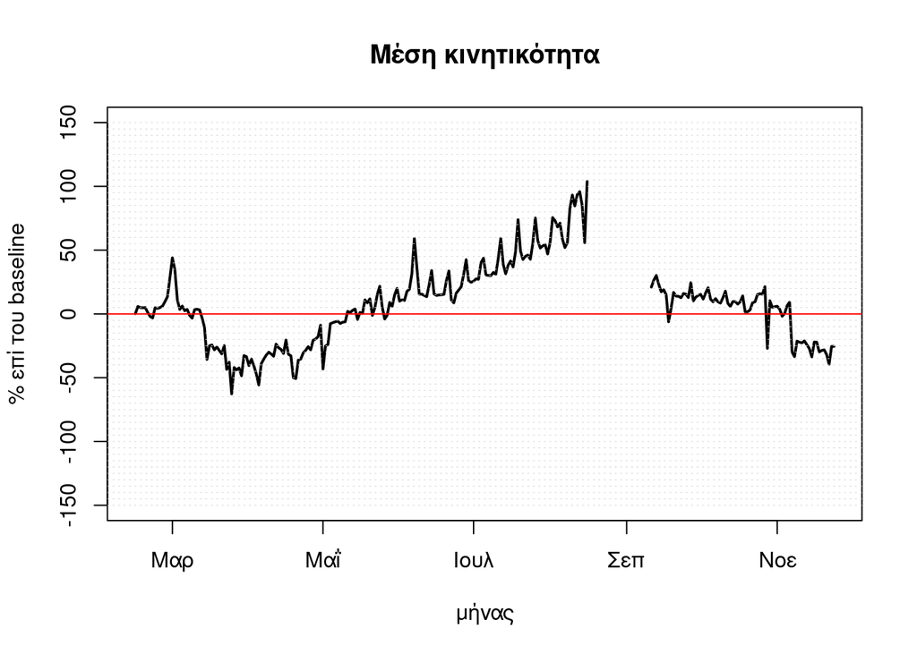

### **Κινητικότητα ανά δραστηριότητα (από 15/02/2020 έως σήμερα)**

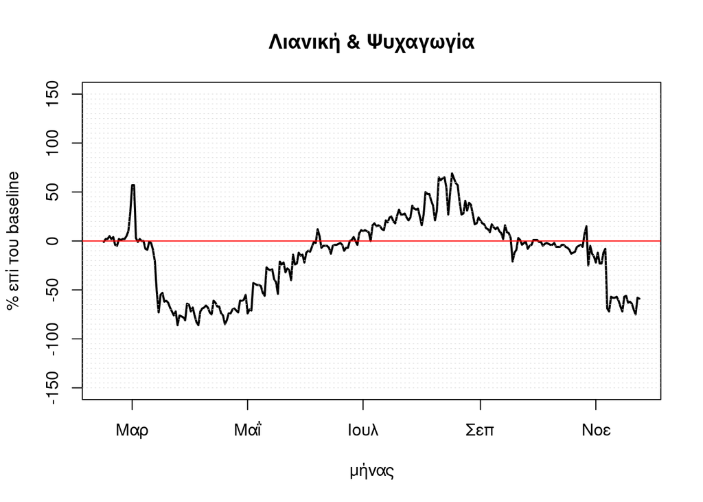

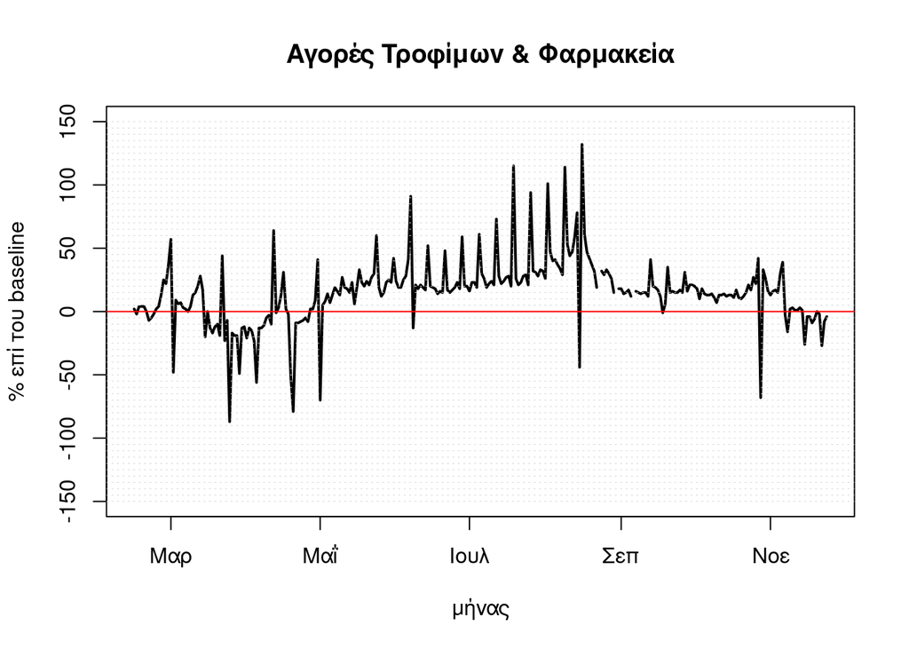

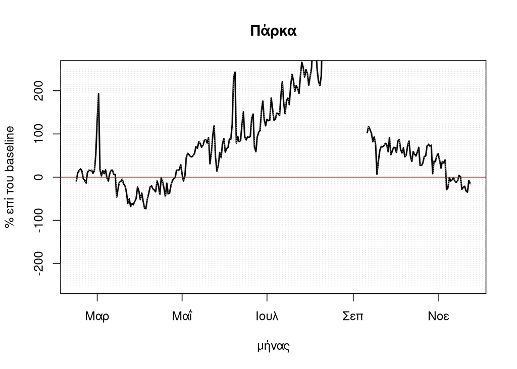

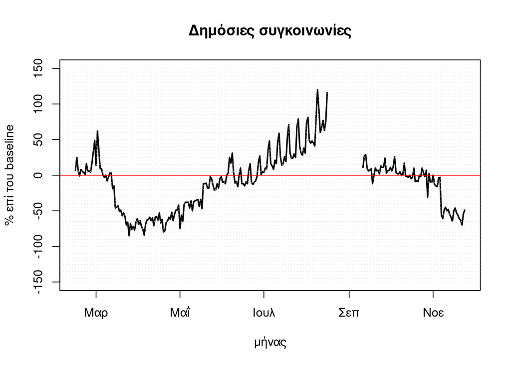

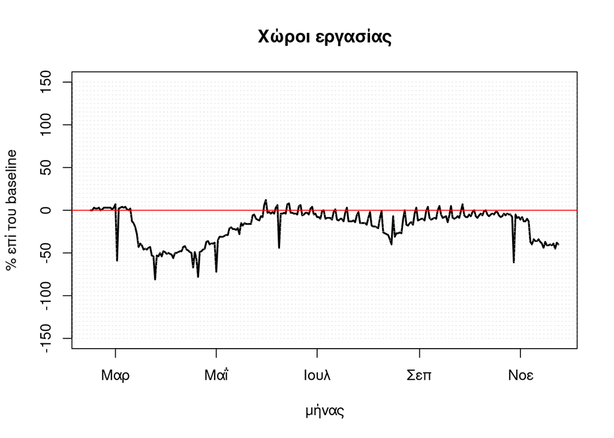

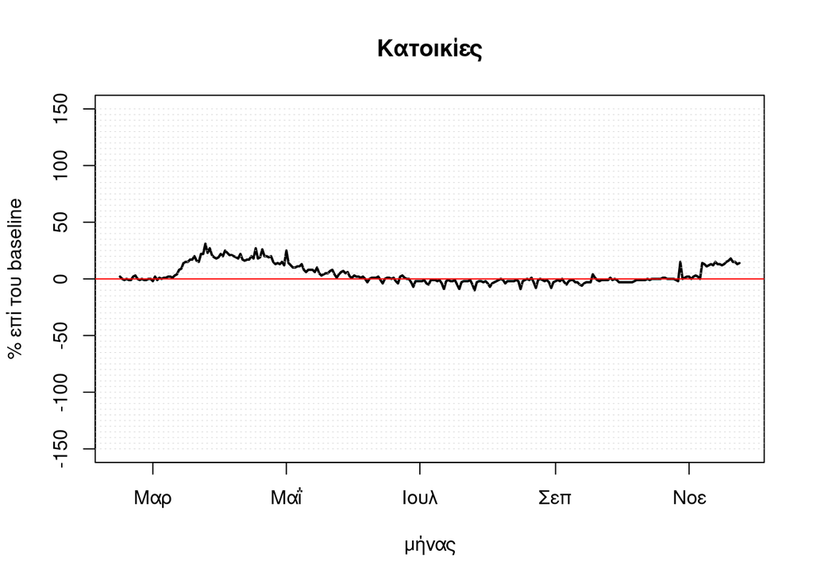

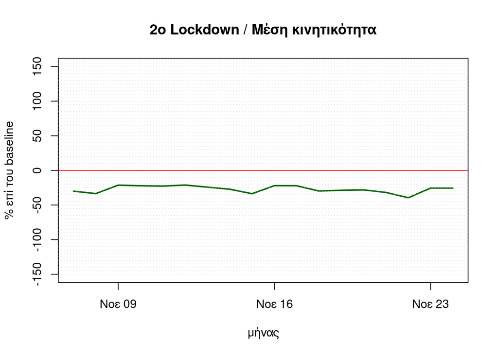

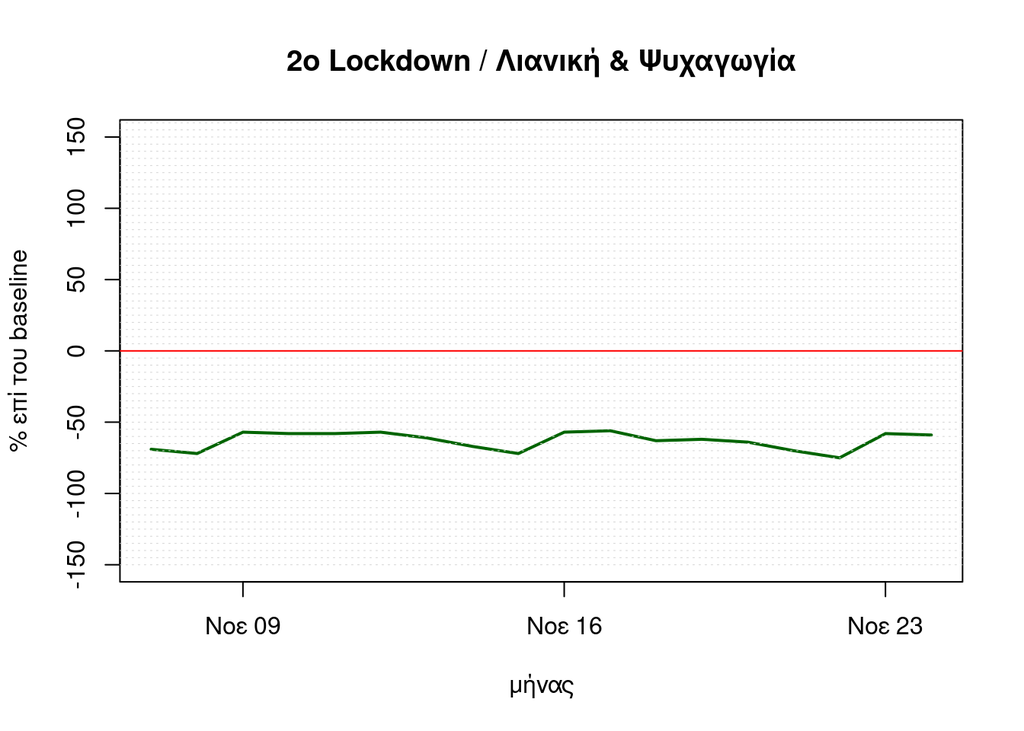

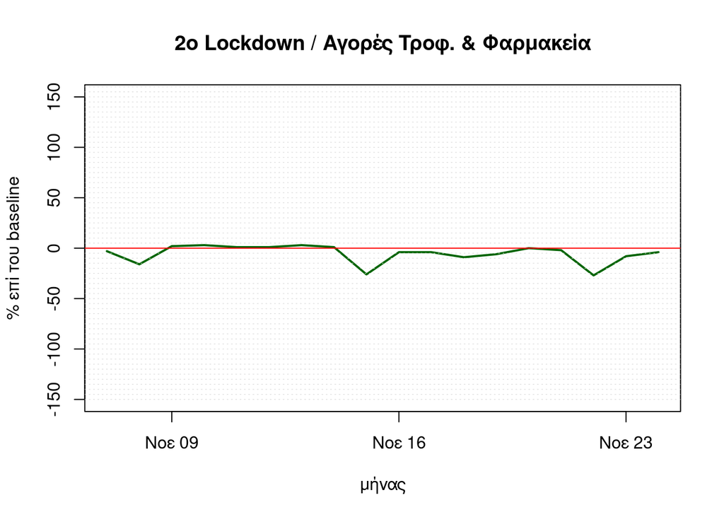

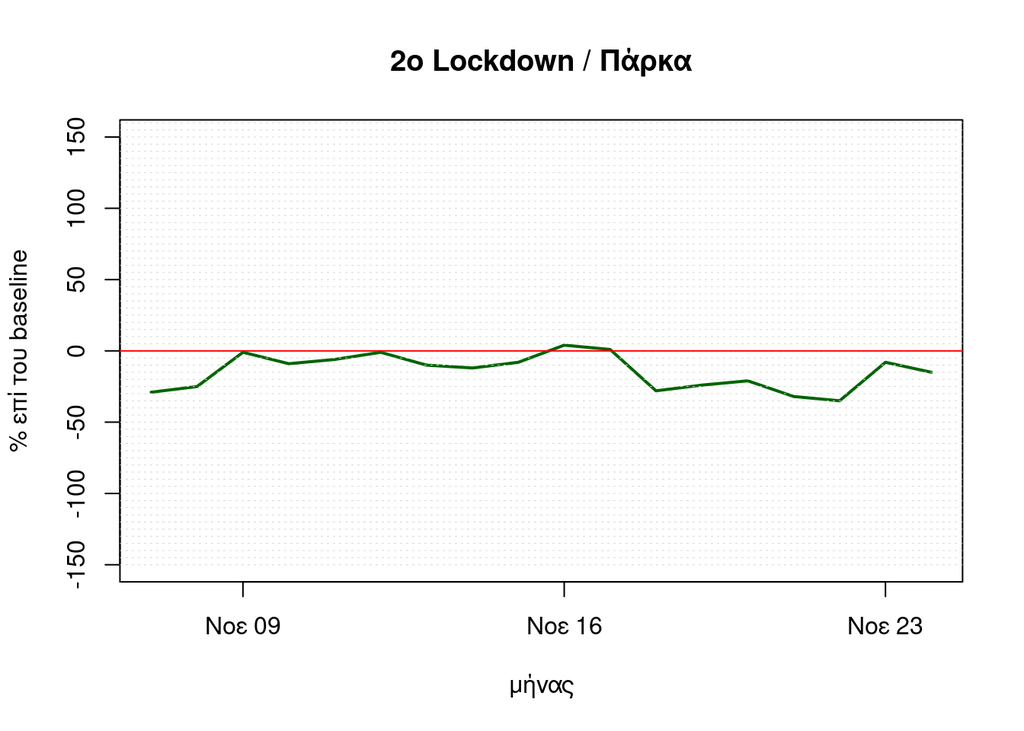

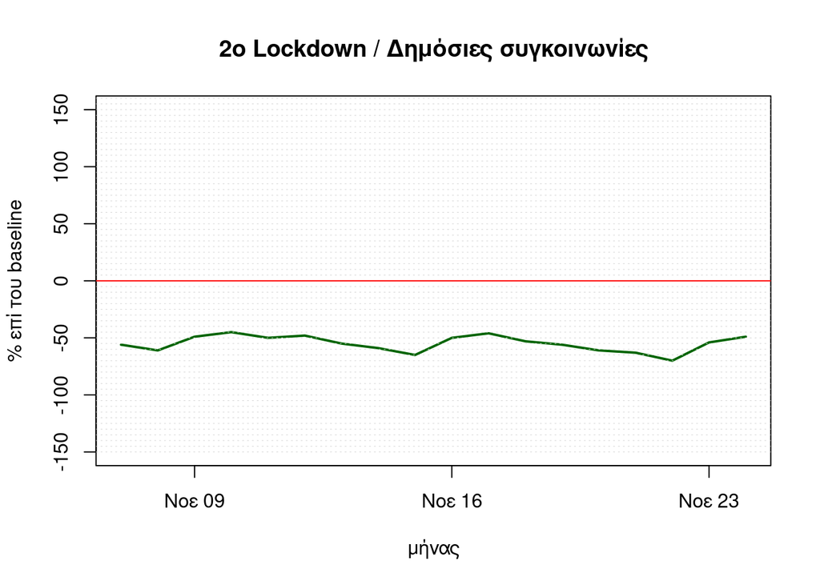

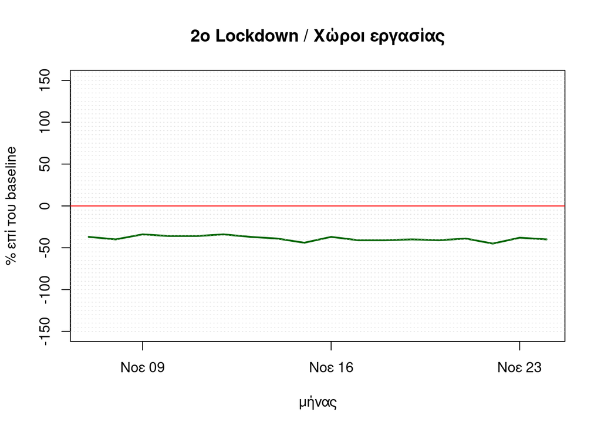

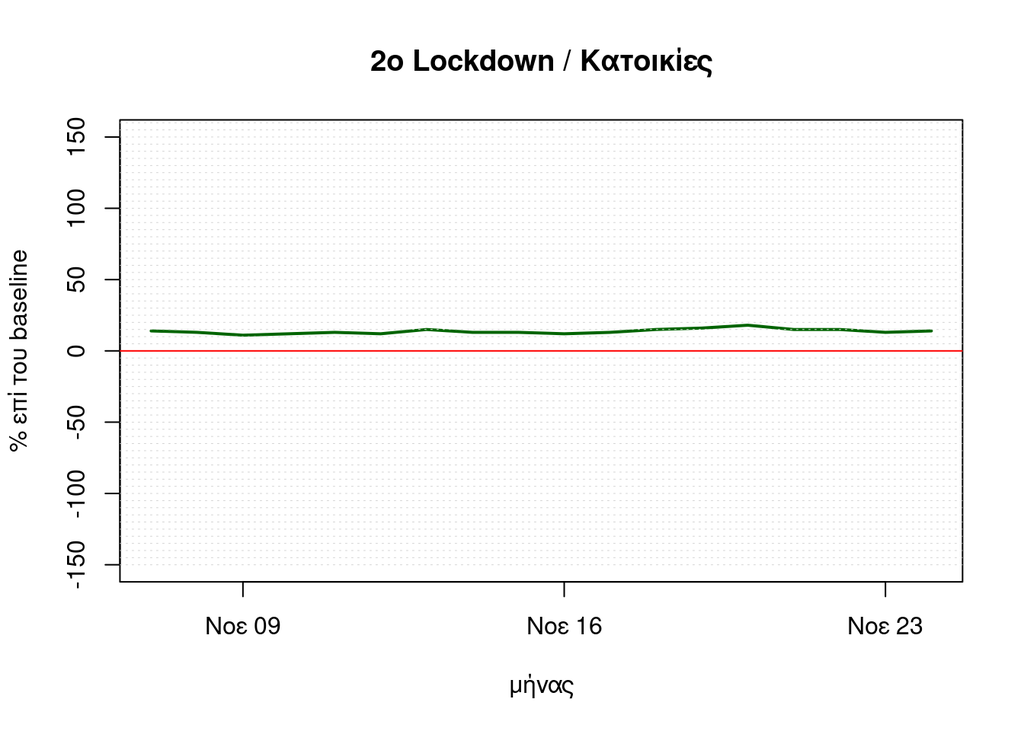

### **Μέση κινητικότητα κατά τη διάρκεια του 1ου Lockdown (από 23/03/2020 έως 04/05/2020)**

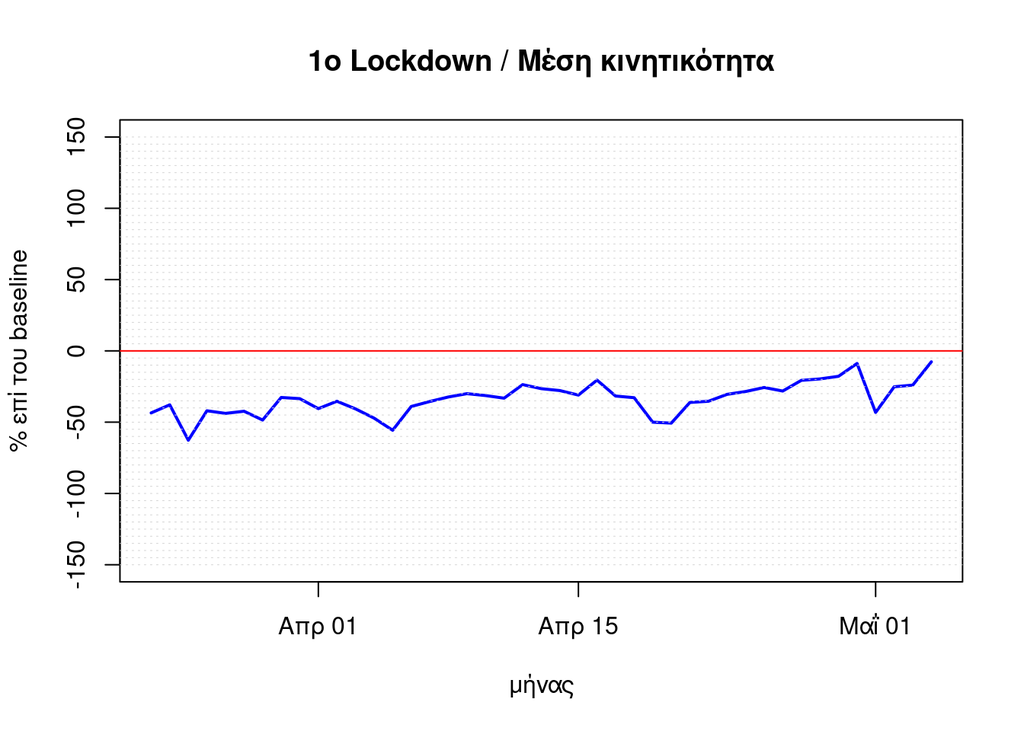

### **Κινητικότητα ανά δραστηριότητα κατά τη διάρκεια του 1ου Lockdown (από 23/03/2020 έως 04/05/2020)**

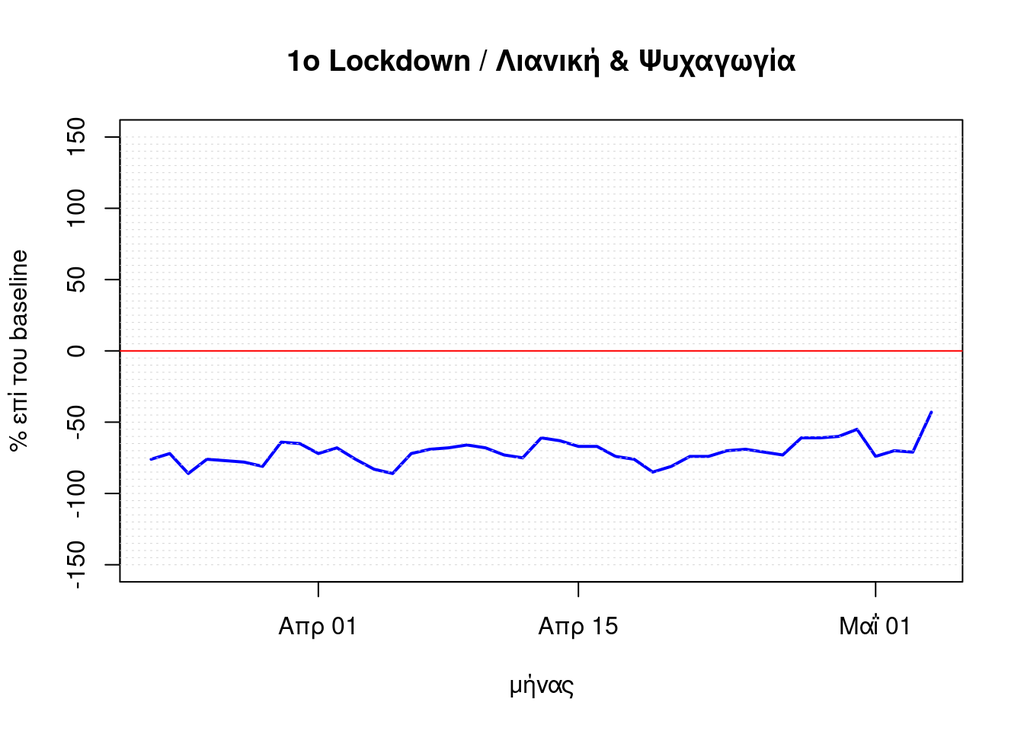

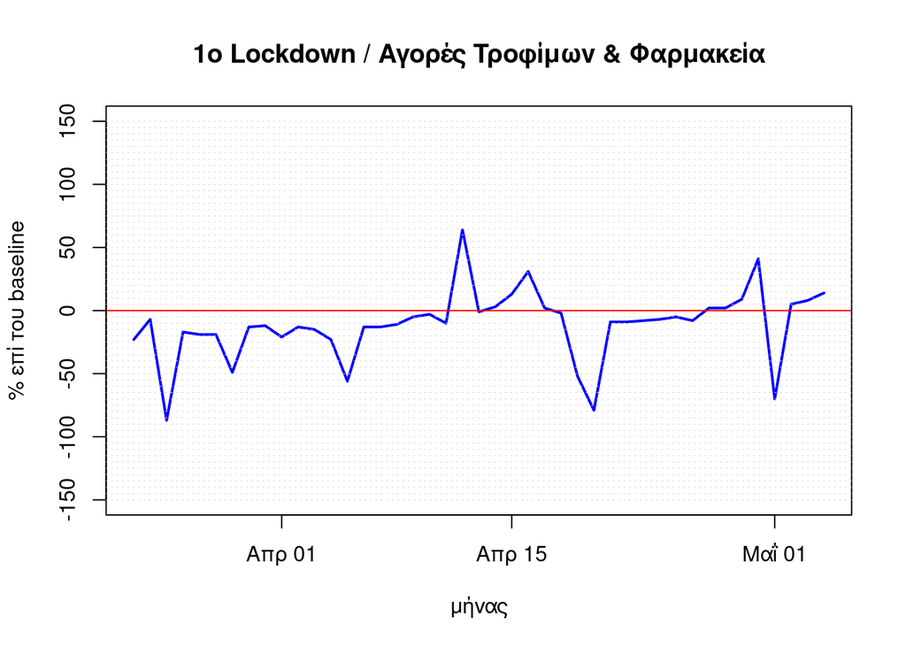

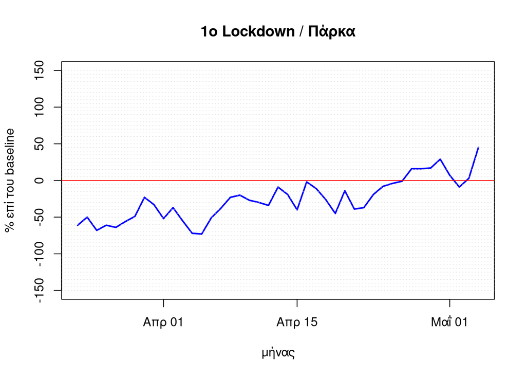

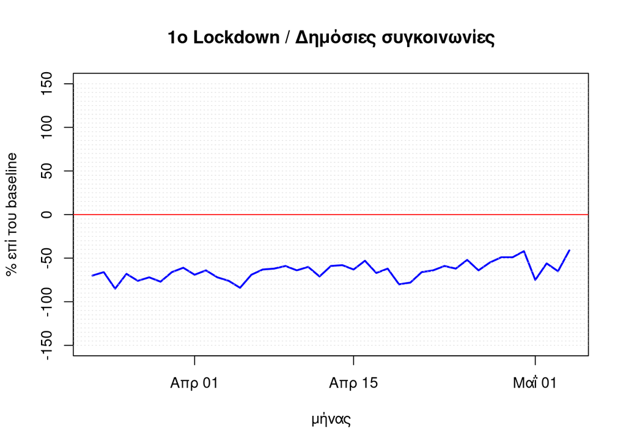

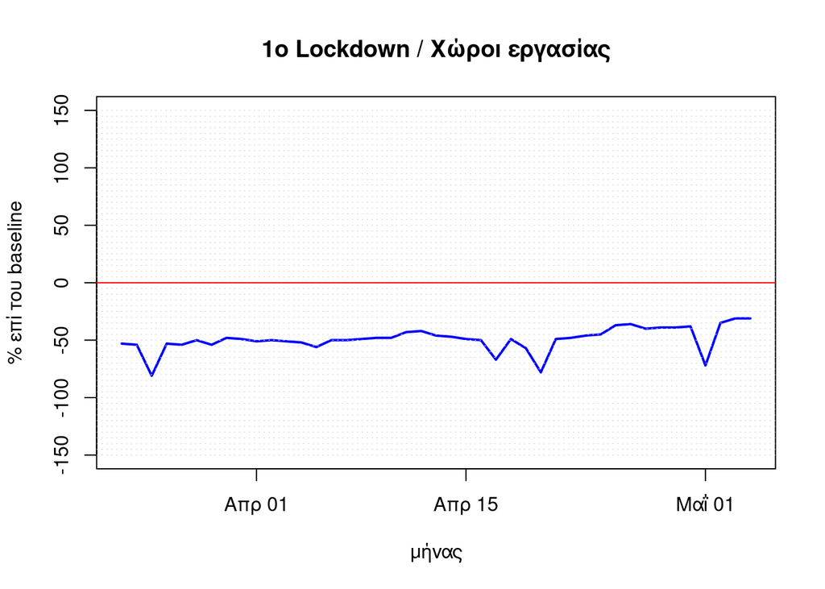

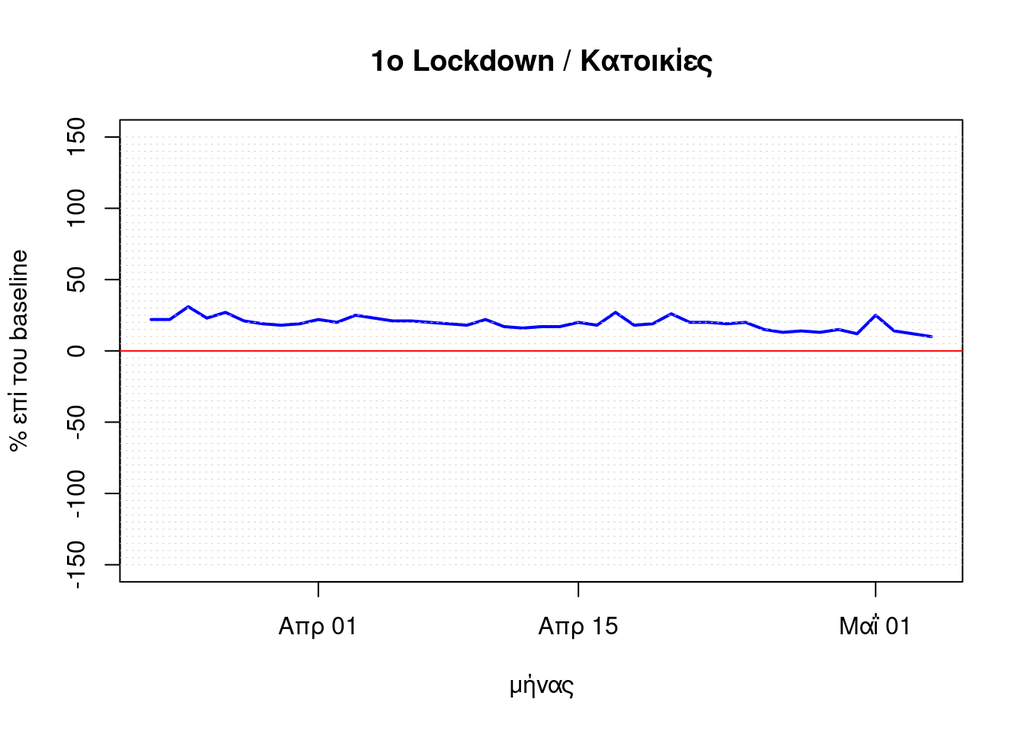

### **Μέση κινητικότητα. Συνδυαστικές καμπύλες 1ου και 2ου Lockdown.**

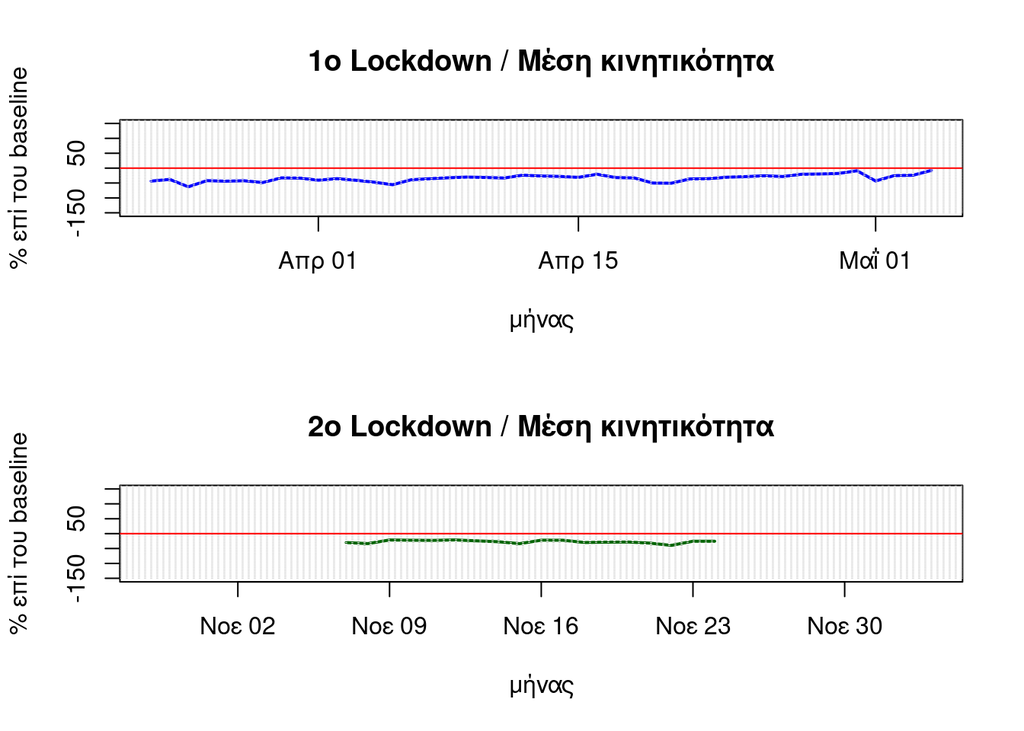

### **Μέση κινητικότητα ανά δραστηριότητα. Συνδυαστικές καμπύλες 1ου και 2ου Lockdown.**

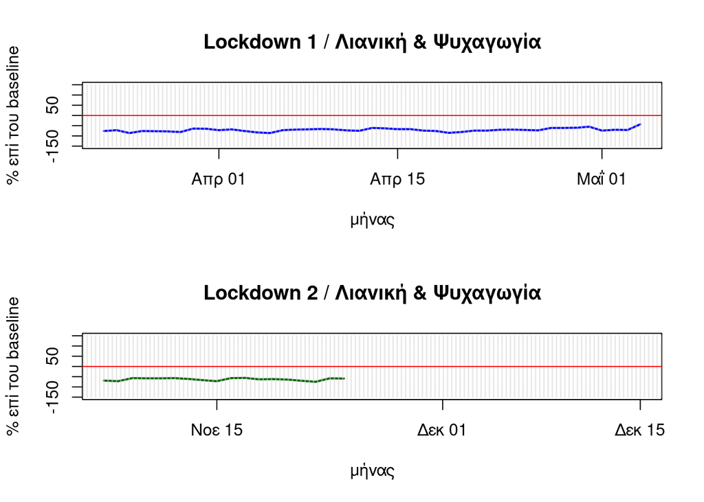

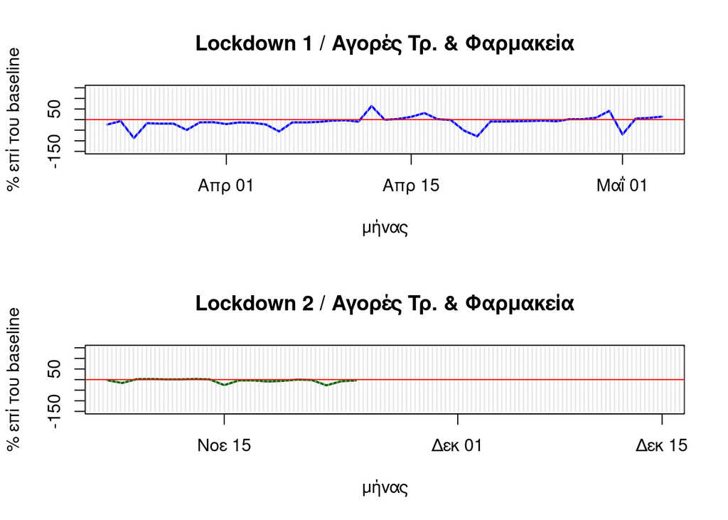

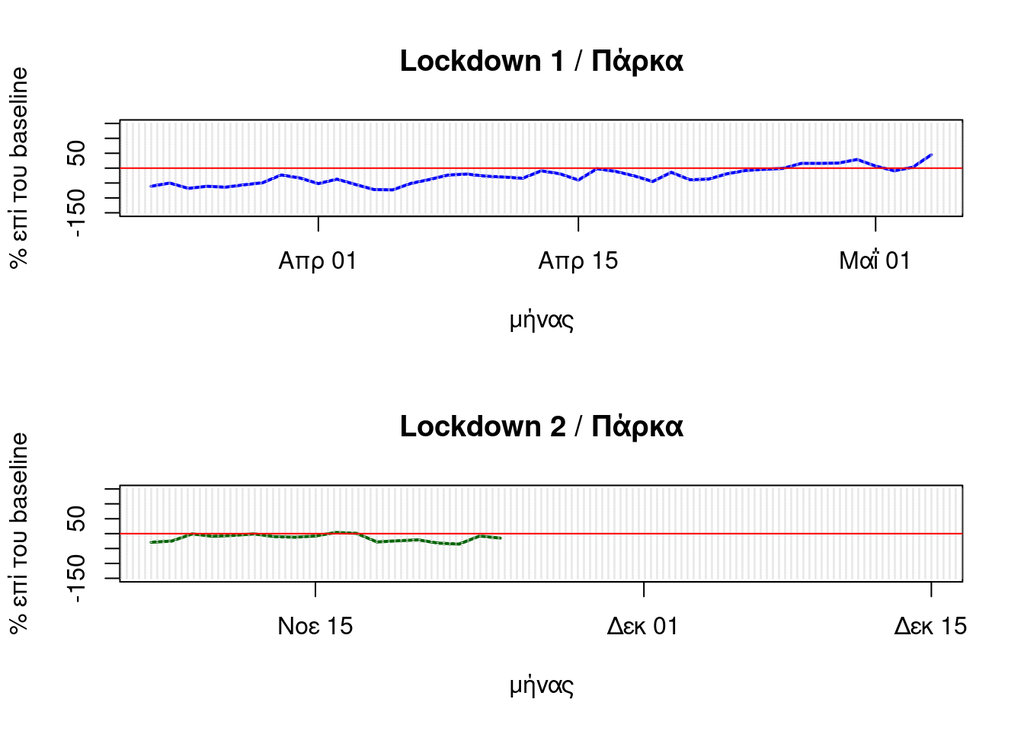

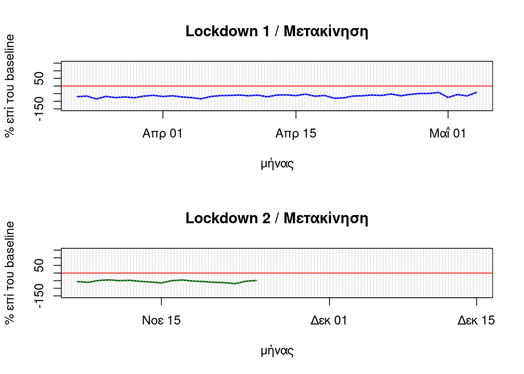

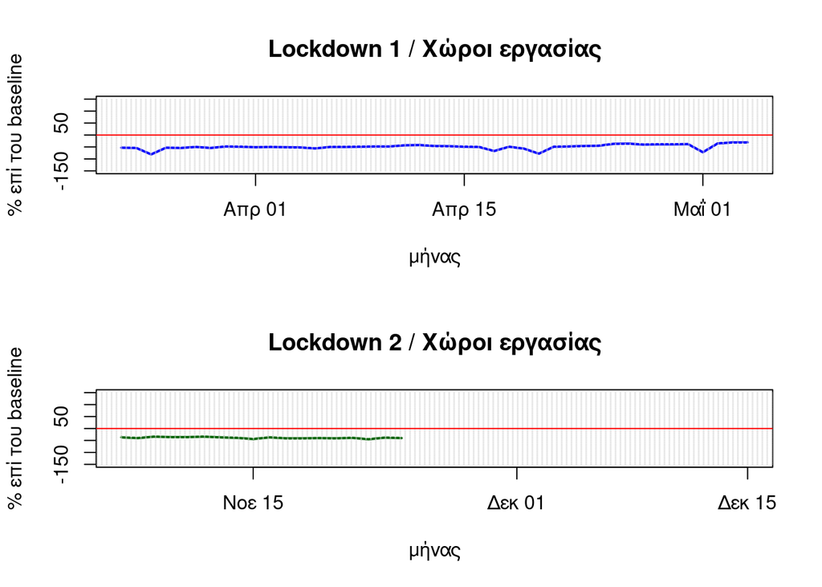

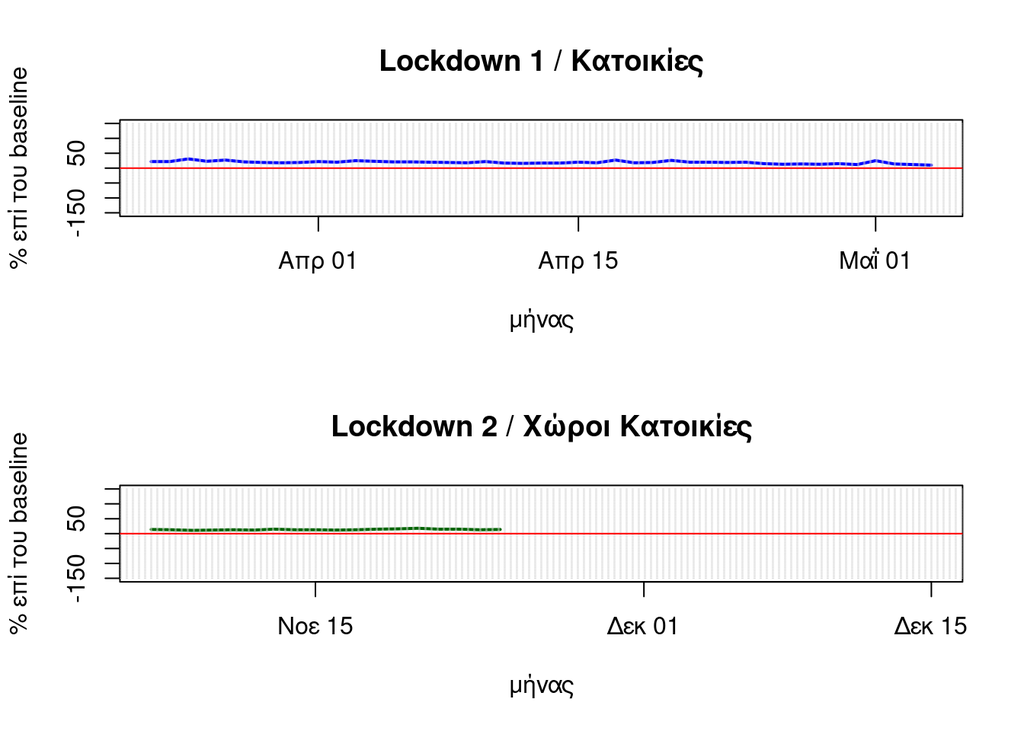